# 2.3.1 LNCaP LOY vs sgCTRL — RNA-seq base analysis

### TCGA-PRAD ARACNe

```
## msVIPER ARACNe (LOY vs sgCTRL): 2545 TFs, 259 at FDR<0.05
```

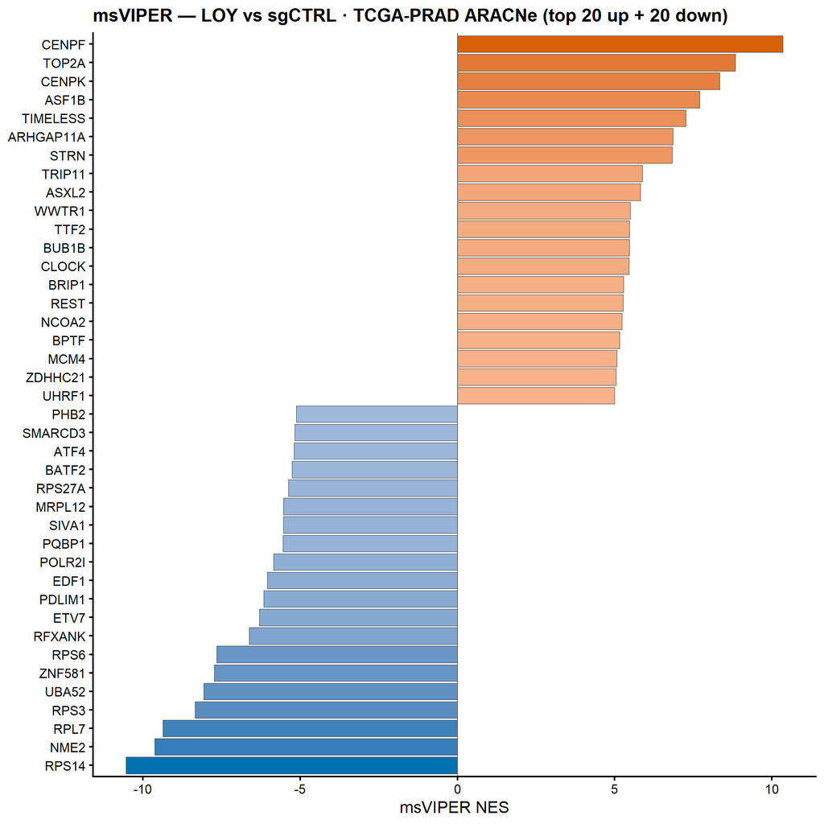

```
## Saved: msviper_bar_LOY_v_sgCTRL_aracne_prad.(png|pdf)  [7x8 in]
```

### TRRUST v2

```
## msVIPER TRRUST (LOY vs sgCTRL): 39 TFs, 3 at FDR<0.05
```

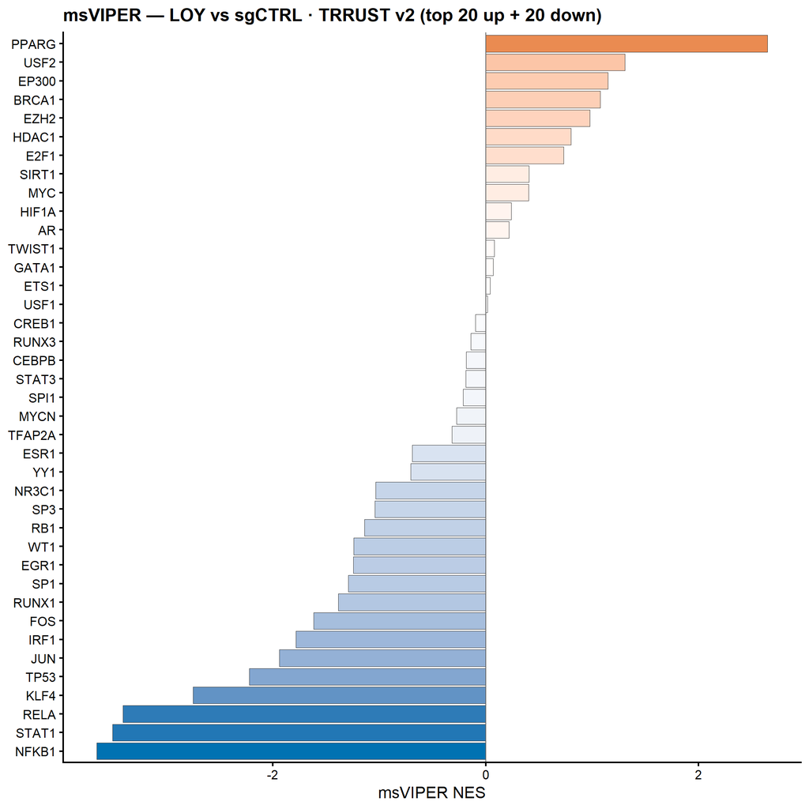

```
## Saved: msviper_bar_LOY_v_sgCTRL_trrust.(png|pdf)  [7x8 in]
```

### MSigDB C3:TFT:GTRD

```
## msVIPER MSigDB C3:TFT:GTRD (LOY vs sgCTRL): 398 TFs, 25 at FDR<0.05
```

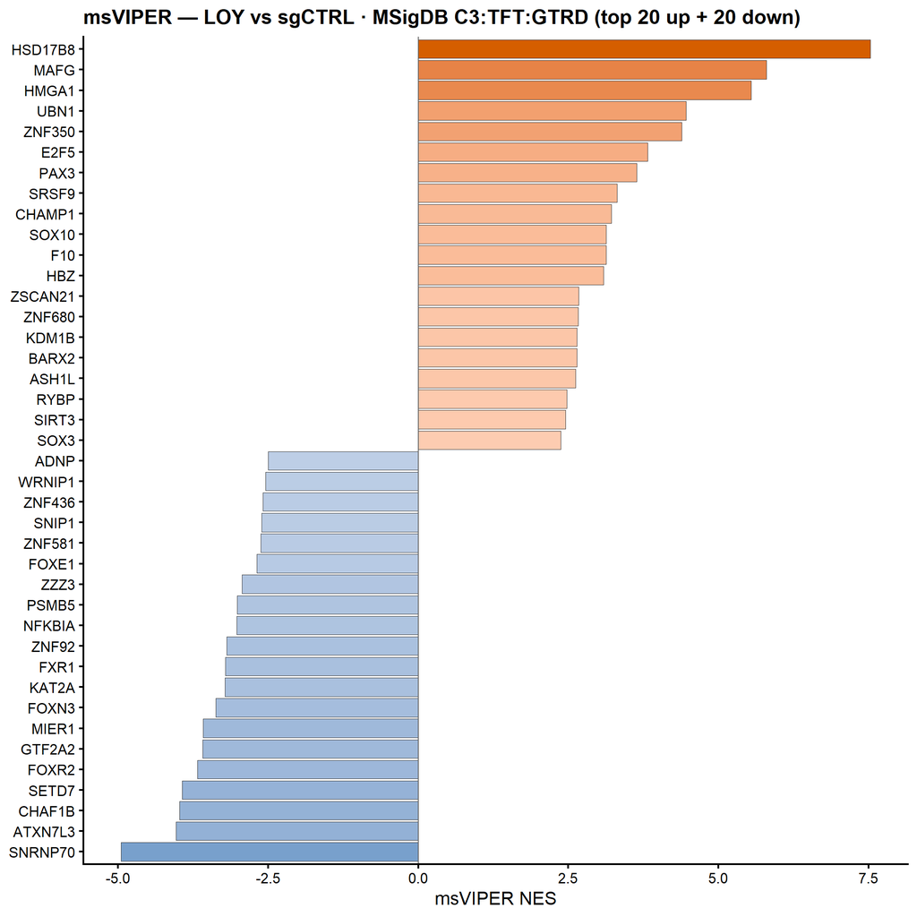

```
## Saved: msviper_bar_LOY_v_sgCTRL_msigdb_tft.(png|pdf)  [7x8 in]
```

# 12. Cross-method TF consistency

This section integrates **every TF result generated above** for the LNCaP LOY-vs-sgCTRL contrast — seven methods × one contrast — and asks: **which TFs are flagged consistently across methods, and which are single-method outliers?**

| # | Method | Regulon source | Inference |
| --- | --- | --- | --- |
| 1 | DoRothEA | DoRothEA pancancer A/B/C | fgsea |
| 2 | decoupleR_CollecTRI | CollecTRI | ULM |
| 3 | decoupleR_TRRUST | TRRUST v2 (literature, curated) | ULM |
| 4 | msVIPER_CollecTRI | CollecTRI | msVIPER |
| 5 | msVIPER_ARACNe | TCGA-PRAD ARACNe (tissue-matched) | msVIPER |
| 6 | msVIPER_TRRUST | TRRUST v2 | msVIPER |
| 7 | msVIPER_TFT | MSigDB C3:TFT:GTRD (ChIP) | msVIPER |

LNCaP has no PARENTAL arm and no pooled-baseline contrast, so the cross-method agreement on the single LOY-vs-sgCTRL contrast is the only consistency axis available here. Cross-cell-line agreement against the A549 and HT1080 robust hits is deferred to the combined analysis (`2.4_rnaseq_combined.Rmd`).

## 12.1 Aggregate all TF NES results

TF result counts by source (LOY vs sgCTRL)

| source | tested | sig |
| --- | --- | --- |
| DoRothEA | 231 | 13 |
| decoupleR_CollecTRI | 638 | 79 |
| decoupleR_TRRUST | 236 | 39 |
| msVIPER_ARACNe | 2545 | 259 |
| msVIPER_CollecTRI | 252 | 16 |
| msVIPER_TFT | 398 | 25 |
| msVIPER_TRRUST | 39 | 3 |

## 12.2 Consistency heatmap (top robust TFs)

Score each TF by how many of the **seven methods** flag it as significant (max = 7). Heatmap the NES of the top scorers across all seven method columns.

```
## TFs significant in >=4 of 7 methods: 4 (showing top 4)
```

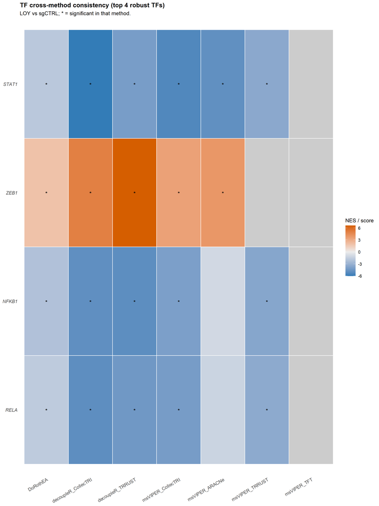

```
## Saved: tf_consistency_heatmap.(png|pdf)  [7x10 in]
```

## 12.3 Robust hits — TFs flagged by multiple methods

Robust hits: TFs significant in at least **five of the seven methods**. The direction (NES sign) is also reported so up- and down-regulated TFs can be read separately.

```
## Robust LNCaP LOY TFs (significant in >=5 of 7 methods): 4
```

Top 30 robust LNCaP LOY TFs (>=5 of 7 methods agree)

| TF | sig_count | NES_direction_mean | sig_sources |
| --- | --- | --- | --- |
| STAT1 | 6 | -4.28 | DoRothEA, decoupleR_CollecTRI, decoupleR_TRRUST, msVIPER_CollecTRI, msVIPER_ARACNe, msVIPER_TRRUST |
| ZEB1 | 5 | 4.19 | DoRothEA, decoupleR_CollecTRI, decoupleR_TRRUST, msVIPER_CollecTRI, msVIPER_ARACNe |
| NFKB1 | 5 | -3.45 | DoRothEA, decoupleR_CollecTRI, decoupleR_TRRUST, msVIPER_CollecTRI, msVIPER_TRRUST |
| RELA | 5 | -3.30 | DoRothEA, decoupleR_CollecTRI, decoupleR_TRRUST, msVIPER_CollecTRI, msVIPER_TRRUST |

# 13. Label-permutation null

How much of what we see in §4–§12 is real biology vs. method-level noise? This section shuffles the **treatment labels** (LOY ↔︎ sgCTRL) across samples *N* times, re-runs the canonical pipeline on each shuffle (unpaired limma–voom DE → Hallmark fgsea → decoupleR ULM TF activity on CollecTRI), and asks: **how often does a random labeling produce as many DEGs / enriched pathways / significant TFs as the real assignment?**

## 13.1 Setup

```
## N permutations: 100   |   class sizes preserved: CTRL=3, LOY=3
```

## 13.2 Helpers

```
## Observed (unpaired, real labels):
```

```
##   N_DEG (FDR<0.05, |lfc|>0.75): 7
```

```
##   N_Hallmark (padj<0.05):   13
```

```
##   N_TF (CollecTRI ULM p<0.05): 53
```

## 13.3 Run permutations

```
## Permutation summary (median [10th–90th percentile]):
```

```
##   n_deg   :      0 [     0 -      7]
##   n_gsea  :     18 [     3 -     26]
##   n_tf    :     66 [    24 -    117]
```

## 13.4 Null vs observed histograms

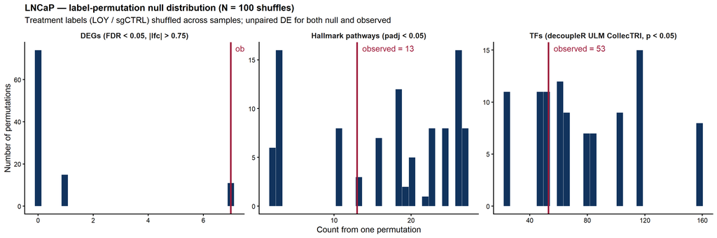

```
## Saved: permutation_null_histograms.(png|pdf)  [12x4 in]
```

## 13.5 Empirical p-values

Permutation-null summary for LNCaP (N = 100 shuffles)

| metric | observed | null_median | null_p10 | null_p90 | empirical_p_right |
| --- | --- | --- | --- | --- | --- |
| DEGs (FDR < 0.05, \|lfc\| > 0.75) | 7 | 0 | 0 | 7 | 0.119 |
| Hallmark pathways (padj < 0.05) | 13 | 18 | 3 | 26 | 0.703 |
| TFs (decoupleR ULM CollecTRI, p < 0.05) | 53 | 66 | 24 | 117 | 0.782 |

**How to read this:** the null distribution shows how many DEGs / pathways / TFs you’d typically recover from a random treatment labeling at the same sample sizes. An empirical p-value near 0 ( = real value far above the null) means the canonical analysis is producing signal well above what random relabeling generates. An empirical p near 1 would mean the real result is indistinguishable from random — i.e. the signal isn’t separable from method-level noise at this sample size.